# Módulo 10c — Rigideces nominales: de Rotemberg a la inflación de 2021–2023

**Curso complementario · puremacro · mazo Slides08 (bloque B2) — mercados no competitivos: precios rígidos y fricciones laborales**

El mazo B2 cubre las semanas 15–16 del calendario; **esta lección es la semana 15** (márgenes, rigidez de precios, no-neutralidad del dinero e inflación 2021–2023). La semana 16 —fricciones laborales, Mortensen–Pissarides, Hosios— es la lección `11_b2`.

### Objetivos de aprendizaje

Al terminar esta lección podrás:

1. Mostrar **por qué con precios flexibles el dinero es neutral** —el margen constante $\mathcal{M}=\varepsilon/(\varepsilon-1)$ clava el costo marginal real— y qué se rompe exactamente cuando ajustar el precio cuesta recursos (**Rotemberg 1982**).
2. Derivar la **curva de Phillips neokeynesiana** $\hat{\pi}_t=\beta E_t\hat{\pi}_{t+1}+\lambda\,\widehat{mc}_t$ con $\lambda=(\varepsilon-1)/\vartheta$, y **verificarla numéricamente** diferenciando la condición exacta de fijación de precios.
3. Resolver el **modelo de tres ecuaciones** (IS dinámica, Phillips, regla de Taylor) con `puremacro.dsge.klein_solve`, leer sus IRF a un choque monetario y a uno de costos, y dibujar el **principio de Taylor** como una frontera de determinación del equilibrio.

Todo corre en Python puro sobre tu **instalación local** de `puremacro` (`pip install puremacro`), leyendo **solo** CSV congelados del bundle del curso — nunca por red.

## 1. El gancho: 2021–2023, el episodio que obligó a volver a lo nominal

Entre 2021 y 2023 la inflación general de Estados Unidos y de México llegó a niveles que ninguna de las dos economías había visto en **años**, y los dos bancos centrales subieron su tasa de política de forma abrupta. Conviene decir *cuántos* años, porque no es el mismo número en los dos países y la frase fácil («cuatro décadas») solo vale para uno: el pico estadounidense de 2022 no se veía desde **1981** —cuatro décadas— pero el mexicano sí se había visto tan tarde como en **diciembre de 2000**, apenas **dos** décadas antes. (Y hacia atrás la asimetría se agranda: México vivió inflaciones de dos y hasta tres dígitos en los ochenta y noventa, de otro orden de magnitud que 2022.) La celda de abajo calcula las dos fechas en vez de pedirte que las creas. El curso hasta aquí ha sido de **ciclos reales**: choques de productividad, cuñas, fricciones de búsqueda. En ese mundo el dinero no hace nada. Este episodio es el recordatorio de que sí hace.

Los datos vienen del **paquete congelado del curso** (`data_curso/bundle_2026A`, descargados de FRED el 2026-08-01 y verificados por hash en su manifiesto):

| serie | contenido | fuente |
| --- | --- | --- |
| `CPIAUCSL` | IPC general EE. UU., índice mensual | FRED / BLS |
| `CPILFESL` | IPC subyacente EE. UU. (sin alimentos ni energía) | FRED / BLS |
| `FEDFUNDS` | tasa de fondos federales efectiva, % anual | FRED / Reserva Federal |
| `CPALTT01MXM659N` | IPC general México, variación anual % | FRED / OCDE-MEI |
| `CPGRLE01MXM659N` | IPC México **sin alimentos ni energía** (definición OCDE), variación anual % | FRED / OCDE-MEI |
| `IR3TIB01MXM156N` | tasa interbancaria a 3 meses de México, % anual | FRED / OCDE-MEI |

Y dos series más que **no** usa esta sección pero sí el mini-entregable de la sección 7:

| serie | contenido | fuente |
| --- | --- | --- |
| `JTSJOL` | vacantes de empleo EE. UU. (JOLTS), **nivel** en miles | FRED / BLS |
| `UNEMPLOY` | desempleados EE. UU., **nivel** en miles | FRED / BLS |

(Estas dos se congelaron el 2026-07-22, no el 2026-08-01 como las de arriba; la fecha de descarga y el `sha256` de cada archivo están en el `manifest.csv` del paquete.)

**Advertencia honesta sobre los datos mexicanos.** Tres cosas que hay que saber antes de leer la figura:

1. **No es la subyacente de INEGI.** `CPGRLE01MXM659N` es el agregado de la OCDE *all items excluding food and energy*, que **no** coincide con la **inflación subyacente oficial** de INEGI/Banxico: la mexicana excluye agropecuarios, energéticos y tarifas autorizadas por el gobierno, pero **sí incluye** los alimentos procesados. La brecha no es cosmética: la subyacente oficial de INEGI tocó **≈8.5% en noviembre de 2022** (dato citado del SIE de Banxico, **no** calculado en este cuaderno), casi **dos puntos** por encima del pico que la celda de abajo imprime para la serie de la OCDE — y eso que las dos hacen pico el mismo mes. La general, en cambio, sí calza con INEGI. Si verificas contra Banxico, verifica contra el concepto correcto.
2. **Las series se descontinuaron.** Los índices de precios de México en FRED (procedentes de OCDE-MEI) terminan en **julio de 2024**; el código imprime la última observación disponible para que lo confirmes tú.
3. **La tasa es un *proxy*.** Graficamos la **interbancaria a 3 meses**, no la tasa objetivo de Banxico. Para el nivel exacto de la tasa objetivo hay que ir al SIE de Banxico, no a esta figura.

```python
def _serie(nombre):
    """Lee un CSV congelado del bundle (una columna de fechas + una de valores)."""
    d = pd.read_csv(DATA / f"{nombre}.csv", parse_dates=["observation_date"])
    return d.set_index("observation_date").iloc[:, 0]

cpi_us   = _serie("CPIAUCSL")            # índice
core_us  = _serie("CPILFESL")            # índice
ffr      = _serie("FEDFUNDS")            # % anual
pi_mx    = _serie("CPALTT01MXM659N")     # ya viene en variación anual %
pic_mx   = _serie("CPGRLE01MXM659N")     # sin alimentos ni energía (OCDE), variación anual %
                                         # OJO: NO es la subyacente oficial de INEGI/Banxico
tiie3m   = _serie("IR3TIB01MXM156N")     # % anual

pi_us  = 100.0 * (cpi_us  / cpi_us.shift(12)  - 1.0)   # variación anual %
pic_us = 100.0 * (core_us / core_us.shift(12) - 1.0)

VENT = slice("2019-01-01", "2024-07-01")   # ventana común: la mexicana termina en jul-2024

def liftoff(tasa, desde="2021-01-01", umbral=0.25):
    """Primer mes desde `desde` con un alza acumulada de 3 meses >= `umbral` (pp)."""
    d = (tasa - tasa.shift(3)).loc[desde:]
    return d[d >= umbral].index[0]

pico_us,  fecha_us  = pi_us[VENT].max(),  pi_us[VENT].idxmax()
picoc_us, fechac_us = pic_us[VENT].max(), pic_us[VENT].idxmax()
pico_mx,  fecha_mx  = pi_mx[VENT].max(),  pi_mx[VENT].idxmax()
picoc_mx, fechac_mx = pic_mx[VENT].max(), pic_mx[VENT].idxmax()
lift_us, lift_mx = liftoff(ffr), liftoff(tiie3m)

print(f"EE. UU.  pico inflación general    = {pico_us:.2f}%  en {fecha_us:%Y-%m}")
print(f"EE. UU.  pico inflación subyacente = {picoc_us:.2f}%  en {fechac_us:%Y-%m}")
print(f"México   pico inflación general    = {pico_mx:.2f}%  en {fecha_mx:%Y-%m}")
print(f"México   pico IPC sin alim. ni energia (def. OCDE) = {picoc_mx:.2f}%  en {fechac_mx:%Y-%m}")
print( "         (NO es la subyacente de INEGI: la oficial tocó ~8.5% en 2022-11, ~2 pp más;")
print( "          cifra citada del SIE de Banxico, no calculada aquí)")
# ¿cuánto hacía que no se veía ese nivel? Última observación ANTERIOR a 2021 que iguala o
# supera el pico del episodio. No es la misma respuesta en los dos países.
_prev_us = pi_us.loc[:"2020-12"];  _prev_mx = pi_mx.loc[:"2020-12"]
ult_us = _prev_us[_prev_us >= pico_us].index[-1]
ult_mx = _prev_mx[_prev_mx >= pico_mx].index[-1]
print(f"\n¿cuánto hacía que no se veía ese nivel? (última obs. previa a 2021 >= el pico)")
print(f"  EE. UU. {ult_us:%Y-%m}  ->  {(fecha_us - ult_us).days/365.25:4.1f} años"
      f"   = cuatro décadas")
print(f"  México  {ult_mx:%Y-%m}  ->  {(fecha_mx - ult_mx).days/365.25:4.1f} años"
      f"   = DOS décadas, no cuatro")

print(f"\ndespegue de la tasa (1er alza trimestral >= 25 pb):")
print(f"  México  {lift_mx:%Y-%m}   |   EE. UU. {lift_us:%Y-%m}"
      f"   -> {round((lift_us - lift_mx).days / 30.4)} meses de diferencia")
print(f"  inflación de EE. UU. cuando la Fed se movió:     {pi_us[lift_us]:.2f}%")
print(f"  inflación de México cuando Banxico se movió:    {pi_mx[lift_mx]:.2f}%")
print(f"  ...y la de EE. UU. ese mismo mes ({lift_mx:%Y-%m}):      {pi_us[lift_mx]:.2f}%"
      f"   <- México NO tenía la inflación más baja de las dos")
print(f"\núltima observación de precios de México en FRED: {pi_mx.index[-1]:%Y-%m}"
      f"   (serie descontinuada)")
```

```
EE. UU.  pico inflación general    = 8.98%  en 2022-06
EE. UU.  pico inflación subyacente = 6.62%  en 2022-09
México   pico inflación general    = 8.70%  en 2022-09
México   pico IPC sin alim. ni energia (def. OCDE) = 6.63%  en 2022-11
         (NO es la subyacente de INEGI: la oficial tocó ~8.5% en 2022-11, ~2 pp más;
          cifra citada del SIE de Banxico, no calculada aquí)

¿cuánto hacía que no se veía ese nivel? (última obs. previa a 2021 >= el pico)
  EE. UU. 1981-11  ->  40.6 años   = cuatro décadas
  México  2000-12  ->  21.7 años   = DOS décadas, no cuatro

despegue de la tasa (1er alza trimestral >= 25 pb):
  México  2021-07   |   EE. UU. 2022-04   -> 9 meses de diferencia
  inflación de EE. UU. cuando la Fed se movió:     8.23%
  inflación de México cuando Banxico se movió:    5.81%
  ...y la de EE. UU. ese mismo mes (2021-07):      5.25%   <- México NO tenía la inflación más baja de las dos

última observación de precios de México en FRED: 2024-07   (serie descontinuada)
```

### Figura 1 — la inflación se adelantó a la tasa

En cada panel: inflación general (línea sólida), la medida sin alimentos ni energía (guiones) y tasa de política (punteada). Escala de grises; la identidad de cada serie está en el **tipo de línea**. En el panel A la línea de guiones **sí** es la subyacente oficial de EE. UU. (`CPILFESL`); en el panel B es el agregado de la **OCDE**, que no es la subyacente de INEGI —por eso las etiquetas de los dos paneles no dicen lo mismo.

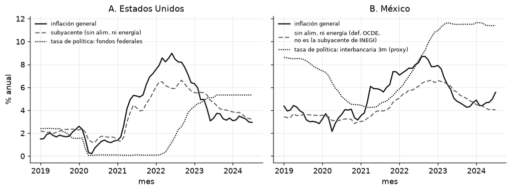

```
Pie: series congeladas de FRED (bundle 2026A, descarga 2026-08-01). Las series de
precios de México terminan en 2024-07 porque FRED las descontinuó;
la tasa mexicana es la interbancaria a 3 meses, proxy de la objetivo de Banxico;
y la linea de guiones del panel B es el agregado de la OCDE sin alimentos ni
energia, NO la inflacion subyacente de INEGI.
```

```python
fig, axes = plt.subplots(1, 2, figsize=(10.2, 3.9), sharey=True)

for ax, (tit, gen, sub, tasa, etq, etq_sub) in zip(axes, [
    ("A. Estados Unidos", pi_us, pic_us, ffr, "fondos federales",
     "subyacente (sin alim. ni energía)"),
    ("B. México",         pi_mx, pic_mx, tiie3m, "interbancaria 3m (proxy)",
     "sin alim. ni energía (def. OCDE,\nno es la subyacente de INEGI)"),
]):
    ax.plot(gen[VENT].index,  gen[VENT].values,  color="0.10", lw=1.7, ls="-",
            label="inflación general")
    ax.plot(sub[VENT].index,  sub[VENT].values,  color="0.40", lw=1.5, ls=(0, (4, 2)),
            label=etq_sub)
    ax.plot(tasa[VENT].index, tasa[VENT].values, color="0.10", lw=1.5, ls=(0, (1, 1)),
            label=f"tasa de política: {etq}")
    ax.axhline(0, color="0.85", lw=0.6)
    ax.set_title(tit); ax.set_xlabel("mes")
    ax.legend(fontsize=8, loc="upper left")
axes[0].set_ylabel("% anual")
plt.tight_layout(); plt.show()

print(f"Pie: series congeladas de FRED (bundle 2026A, descarga 2026-08-01). Las series de\n"
      f"precios de México terminan en {pi_mx.index[-1]:%Y-%m} porque FRED las descontinuó;\n"
      f"la tasa mexicana es la interbancaria a 3 meses, proxy de la objetivo de Banxico;\n"
      f"y la linea de guiones del panel B es el agregado de la OCDE sin alimentos ni\n"
      f"energia, NO la inflacion subyacente de INEGI.")
```

**Lectura.** Los dos picos son casi gemelos en magnitud pero no en fecha, y sobre todo: la **secuencia de la política monetaria fue distinta**. Banxico empezó a subir nueve meses antes que la Reserva Federal, y lo hizo con **su propia** inflación todavía en 5.8%, mientras que la Fed esperó a tener 8.2%. Cuidado con la lectura fácil de esa frase: en julio de 2021 la inflación mexicana **no era menor que la estadounidense** —era mayor, 5.8% contra 5.2%, como imprime la celda—. Lo que difirió no fue el nivel de inflación de cada país sino el **umbral** con el que cada banco central decidió moverse. Un modelo de precios flexibles no tiene nada que decir sobre esta figura: ahí la tasa nominal y el nivel de precios son epifenómenos que no tocan una sola cantidad real. Construyamos el modelo en el que sí importan.

## 2. Con precios flexibles el dinero es neutral (y no es un accidente)

El mazo ya dejó el mercado de productos en competencia monopolista: un continuo de empresas, demanda con elasticidad $\varepsilon$, y una regla de precios $P_{jt}=\mathcal{M}\,\lambda_{jt}$ con margen **constante** $\mathcal{M}=\varepsilon/(\varepsilon-1)$ y $\lambda_{jt}$ el costo marginal nominal. Definiendo el costo marginal **real** $mc_t\equiv\lambda_{jt}/P_t$ y usando el equilibrio simétrico $P_{jt}=P_t$:

$$1=\mathcal{M}\,mc_t\qquad\Longrightarrow\qquad mc_t=\frac{1}{\mathcal{M}}=\frac{\varepsilon-1}{\varepsilon}\quad\text{para todo }t.$$

El costo marginal real queda **clavado en una constante** que solo depende de $\varepsilon$. De la condición de primer orden del trabajo, $mc_t=(W_t/P_t)/\text{PMg}_L$, sale el salario real $w_t=\mathcal{M}^{-1}\,\text{PMg}_L$: el margen es un **impuesto implícito** sobre el pago a los factores, pero es un impuesto de tasa fija.

Ninguna de las ecuaciones del bloque real contiene una variable nominal. Duplicar la cantidad de dinero duplica $P_t$ y $W_t$ y deja intacto todo lo real: la **dicotomía clásica**. La celda siguiente lo hace visible en una economía estática mínima ($y=A\,l$, utilidad $\log c-\chi l^{1+\varphi}/(1+\varphi)$, teoría cuantitativa $M V=P\,y$ para fijar el nivel de precios).

```python
def economia_flexible(M, *, A=1.0, eps=6.0, chi=1.0, varphi=1.0, sigma=1.0, V=1.0):
    """Economía estática con competencia monopolista y precios FLEXIBLES.

    Bloque real: mc = 1/markup (constante) -> w_real = mc*A; oferta de trabajo
    chi*l^varphi = w_real*c^-sigma con c = y = A*l. Bloque nominal: MV = P*y.
    Devuelve un diccionario con las cantidades reales y los precios nominales.
    """
    markup = eps / (eps - 1.0)
    mc = 1.0 / markup                    # costo marginal real: constante
    w_real = mc * A                      # salario real = PMgL / markup
    # chi*l^varphi = w_real*(A*l)^-sigma  ->  l = [w_real*A^-sigma/chi]^(1/(varphi+sigma))
    l = (w_real * A ** (-sigma) / chi) ** (1.0 / (varphi + sigma))
    y = A * l
    P = M * V / y                        # teoría cuantitativa
    return {"markup": markup, "mc": mc, "l": l, "y": y,
            "w_real": w_real, "P": P, "W_nominal": w_real * P}

base   = economia_flexible(M=1.0)
doble  = economia_flexible(M=2.0)

print(f"margen  M = eps/(eps-1) = {base['markup']:.4f}   ->  mc = 1/M = {base['mc']:.4f}"
      f"   ( = (eps-1)/eps = {5/6:.4f} )")
print("\n                    M = 1        M = 2      cambio")
for k, etq in [("l", "empleo"), ("y", "producto"), ("w_real", "salario real"),
               ("P", "nivel de precios"), ("W_nominal", "salario nominal")]:
    print(f"  {etq:18s} {base[k]:8.4f}  {doble[k]:8.4f}   x{doble[k]/base[k]:.2f}")

# La dicotomía clásica, verificada: lo real no se mueve, lo nominal escala uno a uno.
assert np.isclose(base["y"], doble["y"]) and np.isclose(base["w_real"], doble["w_real"])
assert np.isclose(doble["P"] / base["P"], 2.0) and np.isclose(doble["W_nominal"] / base["W_nominal"], 2.0)
```

```
margen  M = eps/(eps-1) = 1.2000   ->  mc = 1/M = 0.8333   ( = (eps-1)/eps = 0.8333 )

                    M = 1        M = 2      cambio
  empleo               0.9129    0.9129   x1.00
  producto             0.9129    0.9129   x1.00
  salario real         0.8333    0.8333   x1.00
  nivel de precios     1.0954    2.1909   x2.00
  salario nominal      0.9129    1.8257   x2.00
```

**El punto que hay que retener.** La neutralidad de arriba no es un resultado numérico frágil: es **estructural**. El código no "encuentra" que el dinero es neutral, lo hereda de que `mc` es una constante y de que ninguna ecuación real ve a `M`. Para romperla no hace falta un mecanismo nuevo —hace falta que el margen **realizado** $\mathcal{M}_t=P_{jt}/\lambda_{jt}$ deje de ser constante. Ahí entra Rotemberg.

## 3. Rigidez a la Rotemberg: el costo de cambiar el precio

**Rotemberg (1982):** cambiar el precio cuesta recursos. La empresa $j$ paga $\frac{\vartheta}{2}\left(P_{jt}/P_{jt-1}-1\right)^{2}Y_t$ en unidades del bien final. Sustituida la demanda $Y_{jt}=(P_{jt}/P_t)^{-\varepsilon}Y_t$, el beneficio real del periodo en función del precio relativo $x_{jt}\equiv P_{jt}/P_t$ es

$$\Pi_{jt}=\underbrace{x_{jt}^{1-\varepsilon}Y_t}_{\text{ingreso}}-\underbrace{mc_t\,x_{jt}^{-\varepsilon}Y_t}_{\text{costo}}-\frac{\vartheta}{2}\left(\frac{P_{jt}}{P_{jt-1}}-1\right)^{2}Y_t .$$

La empresa maximiza $E_0\sum_t Q_{0,t}\Pi_{jt}$. Como $P_{jt}$ aparece hoy **y** en el costo de ajuste de mañana (vía $P_{jt+1}/P_{jt}$), la fijación de precios se vuelve un problema **dinámico**. Derivando y multiplicando por $P_{jt}$, en el equilibrio simétrico ($x_{jt}=1$, $P_{jt}/P_{jt-1}=\pi_t$ la inflación bruta):

$$(1-\varepsilon)+\varepsilon\,mc_t-\vartheta(\pi_t-1)\pi_t+E_t Q_{t,t+1}\,\vartheta(\pi_{t+1}-1)\pi_{t+1}\frac{Y_{t+1}}{Y_t}=0 .$$

**Comprobación de cordura:** con $\vartheta=0$ queda $\varepsilon\,mc_t=\varepsilon-1$, es decir $mc=1/\mathcal{M}$, el caso flexible de la sección 2. La rigidez es una *perturbación* del caso flexible, no otro modelo.

### De la condición exacta a la curva de Phillips

Linealizamos alrededor del estado estacionario de inflación cero: $\pi=1$, $mc=(\varepsilon-1)/\varepsilon$, $Q=\beta$, $Y_{t+1}/Y_t=1$. Escribimos $\pi_t=1+\hat{\pi}_t$ y $mc_t=mc\,(1+\widehat{mc}_t)$. Término a término:

- $\varepsilon\,mc_t=(\varepsilon-1)(1+\widehat{mc}_t)$, que junto con el $(1-\varepsilon)$ deja $(\varepsilon-1)\widehat{mc}_t$;
- $\vartheta(\pi_t-1)\pi_t$ vale cero en $\pi=1$ y su derivada ahí es $\vartheta\left[(\pi_t-1)+\pi_t\right]_{\pi=1}=\vartheta$, así que $\approx\vartheta\hat{\pi}_t$;
- el término adelantado, por lo mismo, $\approx\beta\vartheta\,E_t\hat{\pi}_{t+1}$.

Sumando, $(\varepsilon-1)\widehat{mc}_t-\vartheta\hat{\pi}_t+\beta\vartheta E_t\hat{\pi}_{t+1}=0$, es decir

$$\boxed{\;\hat{\pi}_t=\beta\,E_t\hat{\pi}_{t+1}+\lambda\,\widehat{mc}_t\;},\qquad \lambda=\frac{\varepsilon-1}{\vartheta}.$$

La pendiente **crece con $\varepsilon$** (más competencia, más presión a mover el precio) y **cae con $\vartheta$** (ajustar cuesta más). Iterando hacia adelante, $\hat{\pi}_t=\lambda\sum_{k\ge0}\beta^k E_t\widehat{mc}_{t+k}$: la inflación de hoy es la suma descontada de los **costos marginales futuros esperados**. Y como $\mathcal{M}_t=1/mc_t$, la misma ecuación es $\hat{\pi}_t=\beta E_t\hat{\pi}_{t+1}-\lambda\widehat{\mathcal{M}}_t$: la rigidez de precios no añade una cuña, **endogeniza** la que la competencia monopolista ya había puesto ahí.

En vez de creerle a la derivación, la **verificamos**: diferenciamos numéricamente la condición exacta en el estado estacionario y comparamos cada derivada parcial con el coeficiente analítico.

```python
BETA, EPS = 0.99, 6.0        # descuento trimestral; elasticidad de demanda (margen 20%)

def rotemberg_residual(pi_t, pi_next, mc, *, eps=EPS, vartheta=None, beta=BETA):
    """Condición EXACTA de fijación de precios de Rotemberg en equilibrio simétrico
    (con Q = beta y Y_{t+1}/Y_t = 1). Vale cero en el estado estacionario."""
    return ((1 - eps) + eps * mc
            - vartheta * (pi_t - 1) * pi_t
            + beta * vartheta * (pi_next - 1) * pi_next)

VARTHETA = 58.2524                     # costo de ajuste (calibrado abajo)
mc_ss = (EPS - 1.0) / EPS              # costo marginal real de estado estacionario
h = 1e-5

r0 = rotemberg_residual(1.0, 1.0, mc_ss, vartheta=VARTHETA)
d_pi   = (rotemberg_residual(1+h, 1.0, mc_ss, vartheta=VARTHETA)
          - rotemberg_residual(1-h, 1.0, mc_ss, vartheta=VARTHETA)) / (2*h)
d_pin  = (rotemberg_residual(1.0, 1+h, mc_ss, vartheta=VARTHETA)
          - rotemberg_residual(1.0, 1-h, mc_ss, vartheta=VARTHETA)) / (2*h)
d_mc   = (rotemberg_residual(1.0, 1.0, mc_ss+h, vartheta=VARTHETA)
          - rotemberg_residual(1.0, 1.0, mc_ss-h, vartheta=VARTHETA)) / (2*h)

print(f"residual en el estado estacionario           = {r0:.2e}   (debe ser 0)")
print(f"dR/dpi_t      numérico {d_pi:10.4f}   analítico {-VARTHETA:10.4f}")
print(f"dR/dpi_t+1    numérico {d_pin:10.4f}   analítico {BETA*VARTHETA:10.4f}")
print(f"dR/dmc_t      numérico {d_mc:10.4f}   analítico {EPS:10.4f}")

# El diferencial total  eps*dmc - vartheta*dpi_t + beta*vartheta*dpi_t+1 = 0
# se reescribe, con dmc = mc_ss*mc_hat, como  dpi_t = beta*dpi_t+1 + lambda*mc_hat.
lam_num = -(d_mc * mc_ss) / d_pi          # lambda implícito por diferenciación numérica
beta_num = -d_pin / d_pi                  # beta implícito
print(f"\nlambda  numérico = {lam_num:.6f}   fórmula (eps-1)/vartheta = {(EPS-1)/VARTHETA:.6f}")
print(f"beta    numérico = {beta_num:.6f}   calibrado                = {BETA:.6f}")
assert np.isclose(lam_num, (EPS - 1) / VARTHETA, rtol=1e-6)
assert np.isclose(beta_num, BETA, rtol=1e-8)
```

```
residual en el estado estacionario           = 0.00e+00   (debe ser 0)
dR/dpi_t      numérico   -58.2524   analítico   -58.2524
dR/dpi_t+1    numérico    57.6699   analítico    57.6699
dR/dmc_t      numérico     6.0000   analítico     6.0000

lambda  numérico = 0.085833   fórmula (eps-1)/vartheta = 0.085833
beta    numérico = 0.990000   calibrado                = 0.990000
```

### $\vartheta$, $\varepsilon$ y $\lambda$: cómo se calibra la pendiente

A primer orden la curva de Rotemberg es **idéntica** a la de Calvo, con $\lambda_{\text{Calvo}}=(1-\theta)(1-\beta\theta)/\theta$, donde $\theta$ es la probabilidad de **no** reoptimizar el precio. Igualar ambas pendientes traduce $\vartheta$ en $\theta$ —y es como calibramos $\vartheta$ arriba: fijamos $\theta=0.75$ (precios que duran en promedio $1/(1-\theta)=4$ trimestres) y despejamos $\vartheta=(\varepsilon-1)/\lambda$.

```python
lam_calvo = lambda th, beta=BETA: (1 - th) * (1 - beta * th) / th

theta_obj = 0.75
lam_obj = lam_calvo(theta_obj)
vartheta_obj = (EPS - 1) / lam_obj
print(f"theta = {theta_obj:.2f}  ->  lambda_Calvo = {lam_obj:.6f}"
      f"  ->  vartheta = (eps-1)/lambda = {vartheta_obj:.4f}")
assert np.isclose(vartheta_obj, VARTHETA, atol=1e-3)   # es el valor usado arriba

print("\n  eps   vartheta   lambda=(eps-1)/vartheta   theta Calvo equivalente   duración (trim.)")
for eps_i in (4.0, 6.0, 11.0):
    for vth_i in (30.0, VARTHETA, 120.0):
        lam_i = (eps_i - 1) / vth_i
        # theta que iguala la pendiente de Calvo a lam_i (búsqueda por bisección, sin scipy)
        lo, hi = 1e-4, 1 - 1e-6
        for _ in range(200):
            mid = 0.5 * (lo + hi)
            if lam_calvo(mid) > lam_i: lo = mid
            else: hi = mid
        th_i = 0.5 * (lo + hi)
        print(f" {eps_i:5.1f} {vth_i:9.2f} {lam_i:22.4f} {th_i:22.3f} {1/(1-th_i):16.1f}")
```

```
theta = 0.75  ->  lambda_Calvo = 0.085833  ->  vartheta = (eps-1)/lambda = 58.2524

  eps   vartheta   lambda=(eps-1)/vartheta   theta Calvo equivalente   duración (trim.)
   4.0     30.00                 0.1000                  0.733              3.7
   4.0     58.25                 0.0515                  0.801              5.0
   4.0    120.00                 0.0250                  0.858              7.0
   6.0     30.00                 0.1667                  0.669              3.0
   6.0     58.25                 0.0858                  0.750              4.0
   6.0    120.00                 0.0417                  0.819              5.5
  11.0     30.00                 0.3333                  0.568              2.3
  11.0     58.25                 0.1717                  0.665              3.0
  11.0    120.00                 0.0833                  0.753              4.1
```

**Lectura de la tabla.** Más competencia (mayor $\varepsilon$) o costos de ajuste menores empinan la curva de Phillips y, en la traducción a Calvo, acortan la duración implícita de los precios. La combinación que usamos —$\varepsilon=6$ (margen del 20%) y $\vartheta\approx58$— corresponde a precios que duran cuatro trimestres, el valor de referencia de la literatura de calibración. Es una **elección**, no un dato: la evidencia microeconómica de precios (Bils–Klenow 2004) sugiere duraciones más cortas, y esa tensión entre la pendiente que pide el macro y la que pide el micro sigue abierta.

## 4. El modelo de tres ecuaciones

Cerramos el modelo con tres ecuaciones en desviaciones (todo trimestral), con $\tilde{y}_t$ la brecha del producto, $\hat{\pi}_t$ la inflación neta e $i_t$ la tasa nominal:

$$\text{IS dinámica:}\qquad \tilde{y}_t=E_t\tilde{y}_{t+1}-\tfrac{1}{\sigma}\left(i_t-E_t\hat{\pi}_{t+1}-r^n_t\right)$$ $$\text{Phillips:}\qquad \hat{\pi}_t=\beta E_t\hat{\pi}_{t+1}+\kappa\,\tilde{y}_t+u_t,\qquad \kappa=\lambda\psi$$ $$\text{Taylor:}\qquad i_t=r^n_t+\phi_\pi\hat{\pi}_t+\phi_y\tilde{y}_t+v_t$$

donde $\psi>0$ es el **traspaso de la brecha al costo marginal** ($\widehat{mc}_t=\psi\tilde{y}_t$; sin capital, $\psi=\sigma+\varphi$), $v_t$ es un choque de **política monetaria** y $u_t$ un choque de **costos** (*cost-push*), ambos AR(1). La tasa natural $r^n_t$ entra como dato y se cancela al sustituir la regla en la IS.

Para que la lección permita también la sección 6, escribimos la Phillips en su versión **híbrida** $\hat{\pi}_t=\gamma\hat{\pi}_{t-1}+\beta(1-\gamma)E_t\hat{\pi}_{t+1}+\kappa\tilde{y}_t+u_t$; con $\gamma=0$ —el caso de esta sección— es exactamente la curva derivada arriba.

El sistema se escribe en la forma de Klein $A\,E_t z_{t+1}=B\,z_t$ con $z_t=[v_t,\;u_t,\;\hat{\pi}_{t-1}\;|\;\tilde{y}_t,\;\hat{\pi}_t]$: tres variables **predeterminadas** y dos de **salto**.

```python
from puremacro.dsge import klein_solve

SIGMA, VARPHI = 1.0, 1.0                 # aversión al riesgo; inversa de la Frisch
PSI   = SIGMA + VARPHI                   # traspaso de la brecha al costo marginal
LAM   = (EPS - 1) / VARTHETA             # pendiente de la Phillips en el costo marginal
KAPPA = LAM * PSI                        # pendiente en la brecha
RHO_V, RHO_U = 0.5, 0.8                  # persistencia de los choques
IV, IU, IPL, IY, IPI = 0, 1, 2, 3, 4     # posiciones en z
N_PRE = 3

def nk_sistema(phi_pi, phi_y, gamma=0.0, kappa=KAPPA, beta=BETA, sigma=SIGMA):
    """Matrices (A, B) del modelo de tres ecuaciones en la forma A E_t z_{t+1} = B z_t."""
    A = np.zeros((5, 5)); B = np.zeros((5, 5))
    A[0, IV] = 1.0;  B[0, IV] = RHO_V                        # v_{t+1} = rho_v v_t
    A[1, IU] = 1.0;  B[1, IU] = RHO_U                        # u_{t+1} = rho_u u_t
    A[2, IPL] = 1.0; B[2, IPI] = 1.0                         # pi_lag_{t+1} = pi_t
    A[3, IY] = 1.0;  A[3, IPI] = 1.0 / sigma                 # IS (con Taylor sustituida)
    B[3, IV] = 1.0 / sigma; B[3, IY] = 1.0 + phi_y / sigma; B[3, IPI] = phi_pi / sigma
    A[4, IPI] = beta * (1 - gamma)                           # Phillips (híbrida si gamma>0)
    B[4, IU] = -1.0; B[4, IPL] = -gamma; B[4, IY] = -kappa; B[4, IPI] = 1.0
    return A, B

PHI_PI, PHI_Y = 1.5, 0.125               # Taylor (1993), trimestral: 1.5 y 0.5/4
sol = klein_solve(*nk_sistema(PHI_PI, PHI_Y), N_PRE)
print(f"calibración:  beta={BETA}  sigma={SIGMA}  varphi={VARPHI}  eps={EPS}"
      f"  vartheta={VARTHETA:.2f}")
print(f"              lambda={LAM:.4f}  psi={PSI}  kappa=lambda*psi={KAPPA:.4f}")
print(f"              phi_pi={PHI_PI}  phi_y={PHI_Y}  rho_v={RHO_V}  rho_u={RHO_U}")
print(f"\nklein_solve: eu = {sol.eu}   (1,1) = solución estable única")
print(f"módulos de los autovalores: {np.round(np.sort(np.abs(sol.eigenvalues)), 3)}")
print(f"  -> {int((np.abs(sol.eigenvalues) > 1 + 1e-9).sum())} fuera del círculo unitario;"
      f" hacen falta exactamente {5 - N_PRE} (las variables de salto)")
assert sol.eu == (1, 1)
```

```
calibración:  beta=0.99  sigma=1.0  varphi=1.0  eps=6.0  vartheta=58.25
              lambda=0.0858  psi=2.0  kappa=lambda*psi=0.1717
              phi_pi=1.5  phi_y=0.125  rho_v=0.5  rho_u=0.8

klein_solve: eu = (1, 1)   (1,1) = solución estable única
módulos de los autovalores: [0.    0.5   0.8   1.182 1.182]
  -> 2 fuera del círculo unitario; hacen falta exactamente 2 (las variables de salto)
```

### Las IRF: el mismo modelo, dos choques, dos comovimientos

Con la solución $x_{t+1}=Gx_t$, $y_t=Fx_t$, una IRF es simplemente poner el estado inicial en el choque y dejar correr el sistema. Normalizamos cada choque para que sea legible: el **monetario** eleva la tasa 100 pb anualizados en el impacto; el de **costos** eleva la inflación 100 pb anualizados en el impacto. Inflación y tasa se reportan **anualizadas** ($\times 4$); la brecha, en puntos porcentuales.

```python
H = 13   # horizonte en trimestres (0..12)

def irf(sol, choque, phi_pi=PHI_PI, phi_y=PHI_Y, H=H):
    """IRF por simulación determinista: x_0 = choque, x_{t+1} = G x_t, y_t = F x_t."""
    x = np.zeros((H, N_PRE)); x[0] = choque
    for t in range(1, H):
        x[t] = sol.G @ x[t - 1]
    y = (sol.F @ x.T).T                                   # columnas: [brecha, inflación]
    i = phi_pi * y[:, 1] + phi_y * y[:, 0] + x[:, IV]     # regla de Taylor
    return {"brecha": y[:, 0], "pi": 4 * y[:, 1], "i": 4 * i}   # pi e i anualizadas

mon = irf(sol, [1.0, 0.0, 0.0])
esc_m = 1.00 / mon["i"][0]                                # 100 pb anualizados en el impacto
mon = {k: v * esc_m for k, v in mon.items()}

cost = irf(sol, [0.0, 1.0, 0.0])
esc_c = 1.00 / cost["pi"][0]                              # 100 pb anualizados de inflación
cost = {k: v * esc_c for k, v in cost.items()}

print("CHOQUE MONETARIO (contractivo, +100 pb en el impacto)")
print(f"  brecha del producto en el impacto = {mon['brecha'][0]:+.3f} pp")
print(f"  inflación en el impacto           = {mon['pi'][0]:+.3f} pp anualizados")
print(f"  trimestre del mínimo de la brecha = {int(np.argmin(mon['brecha']))}")
print("CHOQUE DE COSTOS (+100 pb de inflación en el impacto)")
print(f"  brecha del producto en el impacto = {cost['brecha'][0]:+.3f} pp")
print(f"  inflación en el impacto           = {cost['pi'][0]:+.3f} pp anualizados")
print(f"  respuesta de la tasa en el impacto= {cost['i'][0]:+.3f} pp anualizados")

sig_mon  = np.sign(mon['brecha'][0] * mon['pi'][0])
sig_cost = np.sign(cost['brecha'][0] * cost['pi'][0])
print(f"\ncomovimiento producto-precios:  demanda (monetario) = {sig_mon:+.0f}"
      f"   |   oferta (costos) = {sig_cost:+.0f}")
assert sig_mon > 0 and sig_cost < 0    # el signo del comovimiento separa los dos choques
```

```
CHOQUE MONETARIO (contractivo, +100 pb en el impacto)
  brecha del producto en el impacto = -0.758 pp
  inflación en el impacto           = -1.030 pp anualizados
  trimestre del mínimo de la brecha = 0
CHOQUE DE COSTOS (+100 pb de inflación en el impacto)
  brecha del producto en el impacto = -0.538 pp
  inflación en el impacto           = +1.000 pp anualizados
  respuesta de la tasa en el impacto= +1.231 pp anualizados

comovimiento producto-precios:  demanda (monetario) = +1   |   oferta (costos) = -1
```

### Figura 2 — el signo del comovimiento separa demanda de oferta

Izquierda, choque **monetario** (un choque de demanda): la brecha y la inflación caen **juntas**, y el banco central no enfrenta disyuntiva. Derecha, choque de **costos**: la inflación sube mientras la brecha cae —direcciones **opuestas**— y ahí sí hay disyuntiva. Esta figura es la que usaremos en la sección 6 para pensar 2021–2023.

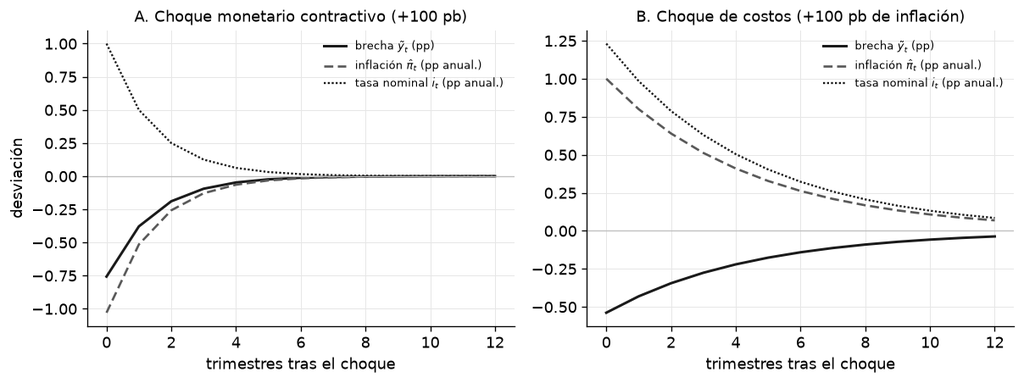

```python
fig, axes = plt.subplots(1, 2, figsize=(10.2, 3.9), sharex=True)
h = np.arange(H)
for ax, d, tit in [(axes[0], mon,  "A. Choque monetario contractivo (+100 pb)"),
                   (axes[1], cost, "B. Choque de costos (+100 pb de inflación)")]:
    ax.plot(h, d["brecha"], color="0.10", lw=1.8, ls="-",          label=r"brecha $\tilde{y}_t$ (pp)")
    ax.plot(h, d["pi"],     color="0.35", lw=1.6, ls=(0, (4, 2)),  label=r"inflación $\hat{\pi}_t$ (pp anual.)")
    ax.plot(h, d["i"],      color="0.10", lw=1.4, ls=(0, (1, 1)),  label=r"tasa nominal $i_t$ (pp anual.)")
    ax.axhline(0, color="0.75", lw=0.8)
    ax.set_title(tit, fontsize=11); ax.set_xlabel("trimestres tras el choque")
    ax.legend(fontsize=8)
axes[0].set_ylabel("desviación")
plt.tight_layout(); plt.show()
```

### El principio de Taylor: dónde el equilibrio deja de ser único

El mazo lo deriva buscando una desviación **constante y autosostenida** ($\hat{\pi}_t=\hat{\pi}$, $\tilde{y}_t=\tilde{y}$, $v_t=0$). La Phillips pide $\tilde{y}=\frac{1-\beta}{\kappa}\hat{\pi}$; la Euler pide que la tasa real no se mueva, $i_t-\hat{\pi}=r^n_t$; y la regla entrega $i_t-r^n_t=\left[\phi_\pi+\phi_y\frac{1-\beta}{\kappa}\right]\hat{\pi}$. Las tres cosas solo son compatibles si

$$\kappa\,(\phi_\pi-1)+(1-\beta)\,\phi_y=0\qquad\text{o bien}\qquad \hat{\pi}=0 .$$

Si el banco central elige coeficientes que hacen esa expresión **positiva**, la única desviación constante posible es $\hat{\pi}=0$ y el equilibrio es **determinado**. Ese es el **principio de Taylor**: con $\phi_y=0$ se reduce a $\phi_\pi>1$. La intuición es directa: si la tasa nominal sube **menos** que la inflación, la tasa **real baja** cuando la inflación sube, la demanda se calienta y la expectativa se valida sola.

Barremos la malla $(\phi_\pi,\phi_y)$ y, en cada punto, preguntamos a `klein_solve` si la condición de Blanchard–Kahn se cumple. La frontera numérica debe coincidir con $\phi_\pi^\*(\phi_y)=1-\frac{(1-\beta)}{\kappa}\phi_y$.

Dos advertencias de lectura de la salida, ambas sobre el **filo** de la condición y ninguna cosmética. Primera: la bandera `eu` de esta versión de `klein_solve` vale `(0,0)` en cualquier fallo de Blanchard–Kahn, tanto si **faltan** autovalores inestables (indeterminación) como si **sobran** (inexistencia); quien distingue los dos casos es el conteo de autovalores, no la bandera. Segunda: justo **en** la frontera hay un autovalor de módulo exactamente 1, y ahí la condición se satisface con **igualdad**: el punto $\phi_\pi=1,\ \phi_y=0$ no es determinado por teoría, aunque el redondeo lo pinte de un lado o del otro. Por eso la celda imprime cuántos puntos de filo hay.

```python
g_pi = np.linspace(0.0, 2.5, 101)      # malla de phi_pi
g_y  = np.linspace(0.0, 2.0, 81)       # malla de phi_y
det = np.zeros((g_y.size, g_pi.size))  # 1 = equilibrio único
nun = np.zeros_like(det)               # autovalores fuera del círculo unitario
eus = {}                               # recuento de banderas eu devueltas
for a, py in enumerate(g_y):
    for b, pp in enumerate(g_pi):
        s_ab = klein_solve(*nk_sistema(pp, py), N_PRE)
        det[a, b] = 1.0 if s_ab.eu == (1, 1) else 0.0
        nun[a, b] = int((np.abs(s_ab.eigenvalues) > 1 + 1e-9).sum())
        eus[s_ab.eu] = eus.get(s_ab.eu, 0) + 1

pendiente = (1 - BETA) / KAPPA          # cuánto phi_pi "compra" cada unidad de phi_y
frontera = 1.0 - pendiente * g_y

print(f"fracción de la malla con equilibrio único = {det.mean():.3f}")
print("autovalores inestables en la malla (hacen falta 2): "
      + ", ".join(f"{int(k)} en {int((nun == k).sum())} puntos"
                  for k in np.unique(nun)))
print("  -> en esta malla el fallo es siempre por DEFECTO: indeterminación, no inexistencia")
print("banderas eu devueltas: "
      + ", ".join(f"{k} en {v} puntos" for k, v in sorted(eus.items())))
print("  OJO con la bandera: esta versión de klein_solve devuelve eu=(0,0) en TODO fallo de")
print("  Blanchard-Kahn, también cuando sobran soluciones. El diagnóstico económico es el")
print("  conteo de autovalores de la línea anterior (1 < 2 = indeterminación), no la bandera.")
_filo = int((det.sum()) - (nun == 2).sum())
print(f"  y hay {_filo} punto(s) de FILO donde los dos conteos discrepan: son los de módulo")
print("  exactamente 1 (phi_pi=1 con phi_y=0). Ahí la condición se cumple con IGUALDAD y la")
print("  teoría no promete unicidad; el signo del redondeo decide, no la economía.")
print(f"pendiente de la frontera  (1-beta)/kappa  = {pendiente:.4f}")
print("\n phi_y   frontera teórica   primer phi_pi determinado en la malla (paso "
      f"{g_pi[1]-g_pi[0]:.3f})")
for py in (0.0, 0.5, 1.0, 2.0):
    fila = det[int(np.argmin(np.abs(g_y - py)))]
    primero = g_pi[np.where(fila > 0)[0][0]]
    print(f" {py:5.2f} {1 - pendiente*py:18.4f} {primero:32.4f}")

# La frontera numérica reproduce la analítica dentro de la resolución de la malla.
assert np.isclose(abs(g_pi[np.where(det[0] > 0)[0][0]] - 1.0), g_pi[1] - g_pi[0], atol=1e-7) or abs(g_pi[np.where(det[0] > 0)[0][0]] - 1.0) <= (g_pi[1] - g_pi[0])

# Autovalores como función de phi_pi (con phi_y = 0): el cruce del círculo unitario.
g_pi2 = np.linspace(0.5, 2.5, 81)
mods = np.array([np.sort(np.abs(klein_solve(*nk_sistema(pp, 0.0), N_PRE).eigenvalues))[-2:]
                 for pp in g_pi2])
```

```
fracción de la malla con equilibrio único = 0.622
autovalores inestables en la malla (hacen falta 2): 1 en 3091 puntos, 2 en 5090 puntos
  -> en esta malla el fallo es siempre por DEFECTO: indeterminación, no inexistencia
banderas eu devueltas: (0, 0) en 3090 puntos, (1, 1) en 5091 puntos
  OJO con la bandera: esta versión de klein_solve devuelve eu=(0,0) en TODO fallo de
  Blanchard-Kahn, también cuando sobran soluciones. El diagnóstico económico es el
  conteo de autovalores de la línea anterior (1 < 2 = indeterminación), no la bandera.
  y hay 1 punto(s) de FILO donde los dos conteos discrepan: son los de módulo
  exactamente 1 (phi_pi=1 con phi_y=0). Ahí la condición se cumple con IGUALDAD y la
  teoría no promete unicidad; el signo del redondeo decide, no la economía.
pendiente de la frontera  (1-beta)/kappa  = 0.0583

 phi_y   frontera teórica   primer phi_pi determinado en la malla (paso 0.025)
  0.00             1.0000                           1.0000
  0.50             0.9709                           0.9750
  1.00             0.9417                           0.9500
  2.00             0.8835                           0.9000
```

### Figura 3 — el corazón de la lección

**Izquierda:** la región donde el equilibrio es **único** (gris claro) y donde no lo es (gris oscuro), con la frontera analítica superpuesta. **Derecha:** los dos módulos de autovalor más grandes; para que la condición de Blanchard–Kahn se cumpla hacen falta **dos** por encima de 1 (hay dos variables de salto), y el segundo cruza el círculo unitario justo en $\phi_\pi=1$.

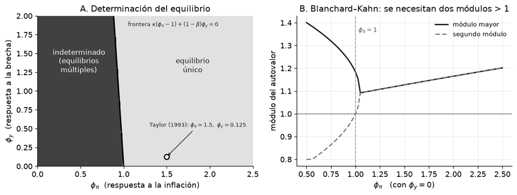

```python
fig, axes = plt.subplots(1, 2, figsize=(10.4, 4.0))

ax = axes[0]
ax.pcolormesh(g_pi, g_y, det, cmap="Greys_r", vmin=-0.35, vmax=1.35, shading="auto")
ax.plot(frontera, g_y, color="0.0", lw=2.0, ls="-")
ax.plot(PHI_PI, PHI_Y, marker="o", ms=7, mfc="white", mec="0.0", mew=1.6, ls="none")
ax.annotate(r"Taylor (1993): $\phi_\pi=1.5,\ \phi_y=0.125$",
            xy=(PHI_PI, PHI_Y), xytext=(1.30, 0.52), fontsize=8, color="0.10",
            arrowprops=dict(arrowstyle="->", color="0.10", lw=0.9))
ax.text(1.05, 1.92, r"frontera $\kappa(\phi_\pi-1)+(1-\beta)\phi_y=0$",
        fontsize=8, color="0.10", va="top", ha="left")
ax.set_xlim(g_pi[0], g_pi[-1]); ax.set_ylim(g_y[0], g_y[-1])
ax.set_xlabel(r"$\phi_\pi$  (respuesta a la inflación)")
ax.set_ylabel(r"$\phi_y$  (respuesta a la brecha)")
ax.set_title("A. Determinación del equilibrio")
ax.text(1.80, 1.25, "equilibrio\núnico", ha="center", fontsize=10, color="0.10")
ax.text(0.48, 1.25, "indeterminado\n(equilibrios\nmúltiples)", ha="center", fontsize=10,
        color="white")
ax.grid(False)

ax = axes[1]
ax.plot(g_pi2, mods[:, 1], color="0.10", lw=1.8, ls="-",         label="módulo mayor")
ax.plot(g_pi2, mods[:, 0], color="0.45", lw=1.6, ls=(0, (4, 2)), label="segundo módulo")
ax.axhline(1.0, color="0.0", lw=1.0, ls=(0, (1, 1)))
ax.axvline(1.0, color="0.55", lw=1.0, ls=(0, (3, 1, 1, 1)))
ax.text(1.03, mods[:, 1].max() * 0.97, r"$\phi_\pi=1$", fontsize=9, color="0.35")
ax.set_xlabel(r"$\phi_\pi$   (con $\phi_y=0$)"); ax.set_ylabel("módulo del autovalor")
ax.set_title("B. Blanchard–Kahn: se necesitan dos módulos > 1")
ax.legend(fontsize=9)
plt.tight_layout(); plt.show()
```

**Lo que hay que ver en el panel A.** La frontera es **casi vertical**. La pendiente $(1-\beta)/\kappa$ impresa arriba dice cuánto $\phi_\pi$ te "compra" cada unidad de $\phi_y$: es diminuta porque $1-\beta\approx0.01$. Responder al producto ayuda, pero apenas; en la práctica el principio de Taylor **es** $\phi_\pi>1$. Y no es un tecnicismo: a la izquierda de esa línea el modelo admite equilibrios de **profecía autocumplida** —la inflación puede subir simplemente porque todos esperan que suba, y la política monetaria la valida. Es la lectura estándar de la *Gran Inflación* de los años setenta (Clarida, Galí y Gertler 2000).

### 4.4 La cota inferior cero (ZLB) y simulación no lineal con OccBin

Cuando un choque negativo de demanda es severo, la regla de Taylor desearía fijar una tasa de interés nominal negativa ($i_t < 0$). Sin embargo, la cota inferior efectiva (Zero Lower Bound, ZLB) $i_t \ge 0$ restringe la política monetaria. En la trampa de liquidez, la tasa nominal no puede caer más, por lo que la deflación esperada eleva la tasa *real* ($r_t = - \mathbb{E}_t \pi_{t+1}$), agravando la caída del producto.

Siguiendo el algoritmo de Guerrieri e Iacoviello (2015), `puremacro.dsge.solve_occbin` resuelve este régimen lineal a trozos de forma exacta mediante iteración regresiva de regímenes.

```python
from puremacro.dsge import build_dynare, solve_occbin, OccBinConstraint

# Régimen de referencia (Taylor activo) y régimen restringido (ZLB: r_t = -r_ss)
variables_nk = ["y", "pi", "r", "g"]
shocks_nk = ["eps_r", "eps_g"]
params_nk = {"beta": 0.99, "sigma": 1.0, "kappa": 0.05, "phi_pi": 1.5, "phi_y": 0.125, "rho_g": 0.8, "r_ss": 0.01}
ss_nk = {v: 0.0 for v in variables_nk}

def nk_ref(lead, curr, lag, shocks_v, p):
    return [
        curr.y - lead.y + (curr.r - lead.pi) / p.sigma - curr.g,
        curr.pi - p.beta * lead.pi - p.kappa * curr.y,
        curr.r - p.phi_pi * curr.pi - p.phi_y * curr.y - shocks_v.eps_r,
        curr.g - p.rho_g * lag.g - shocks_v.eps_g,
    ]

def nk_cons(lead, curr, lag, shocks_v, p):
    return [
        curr.y - lead.y + (curr.r - lead.pi) / p.sigma - curr.g,
        curr.pi - p.beta * lead.pi - p.kappa * curr.y,
        curr.r - (-p.r_ss),
        curr.g - p.rho_g * lag.g - shocks_v.eps_g,
    ]

ref_mod = build_dynare(nk_ref, variables=variables_nk, shocks=shocks_nk, params=params_nk, steady_state=ss_nk)
cons_mod = build_dynare(nk_cons, variables=variables_nk, shocks=shocks_nk, params=params_nk, steady_state=ss_nk, check_steady_state=False, strict=False)

constraint = OccBinConstraint(variable="r", threshold=-params_nk["r_ss"], operator="<")
shock_seq = np.array([0.0, -0.025])
occ_res = solve_occbin(ref_mod, cons_mod, constraint, shock_sequence=shock_seq, horizon=20)
print(f"OccBin ZLB convergencia: {occ_res.converged} | Períodos en ZLB: {int(occ_res.regime_history.sum())}")
assert occ_res.converged
```

[output not shown]

## 5. Confrontación con la evidencia que el curso ya produjo

El curso identifica choques monetarios por tres vías independientes —la **narrativa de Romer y Romer (2004)**, las **sorpresas de alta frecuencia** alrededor de los anuncios de la Reserva Federal (Gertler–Karadi 2015) y las sorpresas equivalentes en los anuncios de Banxico— y las tres coinciden en el mismo hecho: **un endurecimiento monetario no anticipado contrae el producto durante varios trimestres y baja los precios más tarde y menos**. Ese hecho no cabe en ningún modelo de mercados completos y precios flexibles: ahí, como vimos en la sección 2, un choque nominal cambia $P_t$ y nada más.

En el modelo con rigidez a la Rotemberg sí cabe, y con la aritmética exacta: la contracción sube la tasa **real** (principio de Taylor), enfría la demanda y **baja** $\widehat{mc}_t$; bajar $\widehat{mc}_t$ es **subir** el margen $\widehat{\mathcal{M}}_t$, y el margen aprieta la cuña sobre el salario y el rendimiento del capital: caen el empleo y la inversión, y con ellos el producto.

**Dónde falla, dicho sin adornos.** Las IRF *estimadas* tienen forma de **joroba**, con el máximo entre el cuarto y el octavo trimestre, tanto en el producto como en los precios (Ramey 2016; Christiano, Eichenbaum y Evans 2005). La versión que acabamos de resolver responde **de inmediato** y decae de forma monótona: la curva derivada es puramente prospectiva, $\hat{\pi}_t=\lambda\sum_{k\ge0}\beta^k E_t\widehat{mc}_{t+k}$, así que una $\lambda$ finita amortigua el **tamaño** de la respuesta de la inflación, no su **fecha**. La celda siguiente lo comprueba sobre nuestra propia IRF.

**Nota de honestidad sobre los datos.** El bundle congelado de estas lecciones **no** incluye una IRF monetaria estimada, así que aquí no reportamos ninguna cifra empírica calculada: el horizonte del máximo (trimestres 4–8) es una **cita** a Ramey (2016), no un número producido por este cuaderno. Lo único que calculamos es la fecha del máximo del **modelo**.

```python
q_min_y  = int(np.argmin(mon["brecha"]))     # trimestre del mínimo de la brecha
q_min_pi = int(np.argmin(mon["pi"]))         # trimestre del mínimo de la inflación
monot_y  = bool(np.all(np.diff(mon["brecha"][q_min_y:]) >= -1e-12))

print("MODELO (choque monetario contractivo)")
print(f"  máximo efecto sobre la brecha    en el trimestre {q_min_y}")
print(f"  máximo efecto sobre la inflación en el trimestre {q_min_pi}")
print(f"  ¿decae de forma monótona tras el máximo?  {'sí' if monot_y else 'no'}")
print(f"  vida media de la brecha (rho_v = {RHO_V}): "
      f"{np.log(0.5)/np.log(RHO_V):.1f} trimestres")
print("\nDATOS (cita, no cálculo de este cuaderno)")
print("  Ramey (2016) y CEE (2005): máximo de la respuesta entre los trimestres 4 y 8.")
print("  -> el desfase no es un detalle de calibración: el modelo prospectivo puro NO")
print("     puede generar joroba. CEE lo cierran con hábitos en el consumo, costos de")
print("     ajuste de la inversión e indexación de precios. ¿Mecanismos o parches?")
assert q_min_y == 0 and q_min_pi == 0        # el modelo responde en el impacto
```

```
MODELO (choque monetario contractivo)
  máximo efecto sobre la brecha    en el trimestre 0
  máximo efecto sobre la inflación en el trimestre 0
  ¿decae de forma monótona tras el máximo?  sí
  vida media de la brecha (rho_v = 0.5): 1.0 trimestres

DATOS (cita, no cálculo de este cuaderno)
  Ramey (2016) y CEE (2005): máximo de la respuesta entre los trimestres 4 y 8.
  -> el desfase no es un detalle de calibración: el modelo prospectivo puro NO
     puede generar joroba. CEE lo cierran con hábitos en el consumo, costos de
     ajuste de la inversión e indexación de precios. ¿Mecanismos o parches?
```

## 6. La inflación de 2021–2023: tres explicaciones y lo que el modelo puede arbitrar

Tres relatos compitieron por el mismo repunte que graficamos en la sección 1:

- **Demanda.** Estímulo fiscal y monetario sin precedente: el gasto empuja $\tilde{y}_t$ y con él $\widehat{mc}_t$ y la inflación. Predicción distintiva: **producto y precios se mueven en la misma dirección** (panel A de la Figura 2).
- **Oferta.** Energía, alimentos y cuellos de botella en las cadenas de suministro: sube el costo marginal sin que suba la demanda. Predicción distintiva: **producto y precios se mueven en direcciones opuestas** (panel B), y aparece una disyuntiva para la política monetaria que con demanda no existe.
- **Expectativas.** Si $E_t\hat{\pi}_{t+1}$ se **desancla**, la curva de Phillips se desplaza sola y la desinflación exige recesión. Si sigue anclada, la desinflación es barata —que es, de hecho, lo que ocurrió en ambos países.

**Bernanke y Blanchard (2023)** descomponen el episodio con un sistema de precios y salarios en cuatro bloques: energía y alimentos, indicadores de escasez, tensión laboral ($v/u$) y expectativas. Su veredicto: el **arranque** fue de oferta; la **persistencia** de 2022–23, laboral; las expectativas **nunca se desanclaron**.

### Qué representa y qué puede arbitrar el modelo que construimos

**Representa los tres; arbitra dos.** Demanda y oferta entran por $\widehat{mc}_t$ con signos opuestos sobre el producto, y el comovimiento producto-precios es **observable**: eso los separa, y es exactamente el signo que la Figura 2 calculó. El tercero entra por $E_t\hat{\pi}_{t+1}$, que bajo expectativas racionales **no es un dato sino parte de la solución del modelo**; adjudicarlo exige encuestas de expectativas, que este cuaderno no tiene. Representar un canal no es poder atribuirle el episodio.

**Lo que el modelo no puede hacer, dicho sin adornos:** hablar de sectores ni de cuellos de botella ($\widehat{mc}_t$ es una vara agregada); producir una curva de Phillips **no lineal**, que parte de la literatura de 2021–23 considera indispensable (Benigno–Eggertsson 2023); pronunciarse sobre el **traspaso cambiario**, decisivo en México; ni decir nada sobre la tasa real natural, que aquí entra como dato.

La no linealidad está **en disputa**, y conviene no confundir dos objeciones distintas:

- **Ball, Leigh y Mishra (2022)** ajustan el **propio episodio** 2020–2022 con una curva de Phillips **lineal** en la tensión laboral $v/u$ (más un término de expectativas de largo plazo y otro de precios relativos): si con una especificación recta se explica el repunte, la no linealidad deja de ser indispensable.
- **Hazell, Herreño, Nakamura y Steinsson (2022)** son otra cosa: estiman la pendiente con un panel de **estados de EE. UU., 1978–2018**, es decir **antes** del episodio, y lo que encuentran es que la curva es muy **plana** —pendiente pequeña, no necesariamente recta—. Es evidencia previa **contra un empinamiento**, no un ajuste de 2021–23.

Plano y recto no son sinónimos: se puede tener una curva plana en el tramo normal y empinada en el tramo de escasez, que es justo lo que sostienen Benigno y Eggertsson.

### Lo que sí podemos cuantificar: el precio de desanclar las expectativas

La versión híbrida $\hat{\pi}_t=\gamma\hat{\pi}_{t-1}+\beta(1-\gamma)E_t\hat{\pi}_{t+1}+\kappa\tilde{y}_t+u_t$ nos da una manera barata de poner número al tercer relato. Con $\gamma=0$ las expectativas son puramente prospectivas —**ancladas**—; con $\gamma>0$ una parte de la inflación de hoy se hereda de la de ayer, que es lo que hacen la indexación y las expectativas adaptativas. Sometemos ambas economías a un choque de costos **normalizado a la misma inflación de impacto** (+100 pb anualizados) y comparamos.

**Cuidado con qué se mantiene fijo.** Lo que igualamos entre economías **no** es el tamaño del choque $u_t$ sino la inflación que produce en el impacto: como una $\gamma$ mayor amortigua la respuesta contemporánea, hace falta un $u_t$ **más grande** para llegar al mismo +100 pb, y la celda imprime cuánto más grande. Es la comparación pertinente para la pregunta que nos interesa —*revertir la misma inflación observada*, ¿cuánto producto cuesta?—, pero no es «el mismo choque»: si igualáramos $u_t$, la economía con $\gamma$ alta arrancaría además desde una inflación de impacto menor.

**Advertencia:** $\gamma$ es un parámetro que elegimos, no una medición del anclaje de 2021–23. Lo que sigue es una *comparación de modelos*, no una estimación del episodio.

```python
H2 = 25
print(" gamma   u necesario   pico inflación   trim. hasta 1/2 del pico   costo acum. producto")
res = {}
for gamma in (0.0, 0.25, 0.5):
    s_g = klein_solve(*nk_sistema(PHI_PI, PHI_Y, gamma=gamma), N_PRE)
    assert s_g.eu == (1, 1)
    d = irf(s_g, [0.0, 1.0, 0.0], H=H2)
    esc_u = 1.0 / d["pi"][0]          # tamaño de u que da +100 pb de inflación en el impacto
    d = {k: v * esc_u for k, v in d.items()}
    pico = d["pi"].max()
    mitad = int(np.argmax(d["pi"] < pico / 2.0))
    costo = d["brecha"].sum()
    res[gamma] = (pico, mitad, costo, esc_u)
    print(f" {gamma:5.2f} {esc_u:13.4f} {pico:16.3f} {mitad:26d} {costo:23.3f}")

r0_, r5_ = res[0.0], res[0.5]
print(f"\nPara la MISMA inflación de impacto, gamma=0.5 exige un choque u"
      f" {r5_[3]/r0_[3]:.2f} veces mayor que gamma=0 (no es el mismo choque: es el mismo impacto).")
print(f"Desanclar a la mitad (gamma 0 -> 0.5) multiplica el costo acumulado en producto"
      f" por {r5_[2]/r0_[2]:.2f}")
print(f"y alarga de {r0_[1]} a {r5_[1]} trimestres el tiempo hasta que la inflación cae a la"
      f" mitad de su pico.")
assert abs(r5_[2]) > abs(r0_[2])   # con expectativas menos ancladas, la desinflación cuesta más
```

```
 gamma   u necesario   pico inflación   trim. hasta 1/2 del pico   costo acum. producto
  0.00        0.1444            1.000                          4                  -2.682
  0.25        0.1636            1.034                          5                  -3.597
  0.50        0.2209            1.284                          7                  -5.618

Para la MISMA inflación de impacto, gamma=0.5 exige un choque u 1.53 veces mayor que gamma=0 (no es el mismo choque: es el mismo impacto).
Desanclar a la mitad (gamma 0 -> 0.5) multiplica el costo acumulado en producto por 2.09
y alarga de 4 a 7 trimestres el tiempo hasta que la inflación cae a la mitad de su pico.
```

**Lectura.** Partiendo de **la misma inflación de impacto**, la economía con expectativas menos ancladas termina con un pico más alto, una desinflación más lenta y —sobre todo— un episodio **mucho más caro de revertir** en producto. Esa es, en el lenguaje del modelo, la razón por la que el veredicto de Bernanke y Blanchard sobre el **anclaje** importa tanto: si las expectativas se hubieran desanclado, la desinflación de 2022–23 habría exigido la recesión que muchos pronosticaron y que no llegó. Lo que el modelo **no** dice es si estuvieron ancladas: eso lo dicen las encuestas y los *breakevens*, no estas ecuaciones.

## 7. Preguntas para el debate

1. **Si el curso es de ciclos reales, ¿para qué esto?** En el RBC el dinero es neutral por construcción y las fluctuaciones vienen de la tecnología. Pero las tres estrategias de identificación del curso dicen que un choque nominal mueve cantidades reales. ¿Es la rigidez de precios un **mecanismo nuevo** o solo la endogeneización de una cuña que la competencia monopolista ya había puesto en el modelo? Defiende tu respuesta con la ecuación $\hat{\pi}_t=\beta E_t\hat{\pi}_{t+1}-\lambda\widehat{\mathcal{M}}_t$.
2. **La salvedad de Nekarda–Ramey.** El canal de esta lección exige que el margen sea **contracíclico** (que caiga en las expansiones). La evidencia empírica lo mide acíclico o incluso procíclico. ¿Qué le pasa al mecanismo si el dato tiene razón? ¿Se salva cambiando la medición del margen, o hay que cambiar el modelo?
3. **La joroba.** El modelo responde en el impacto; los datos, en el trimestre 4–8. Christiano, Eichenbaum y Evans cierran el hueco con hábitos en el consumo, costos de ajuste de la inversión e **indexación de precios a la inflación pasada**. ¿Cuál de los tres te parece un mecanismo y cuál un parche? Fíjate en que la indexación es exactamente el $\gamma>0$ de la sección 6: ¿es plausible como comportamiento, o solo como forma reducida que hace calzar la IRF?
4. **La figura de la sección 1.** Banxico subió su tasa nueve meses antes que la Fed, con su inflación en 5.8% frente al 8.2% que ya tenía EE. UU. cuando la Fed se movió —aunque en ese julio de 2021 la inflación mexicana era **mayor** que la estadounidense (5.8% contra 5.2%): lo que difirió fue el umbral de reacción, no el nivel de inflación—. En el lenguaje del modelo de tres ecuaciones, ¿qué diferencia entre las dos economías podría justificarlo: una $\phi_\pi$ mayor, una $\lambda$ mayor, o algo que el modelo simplemente no tiene (traspaso cambiario, historia de credibilidad)?

### Mini-entregable (30 min)

Construye la **tensión del mercado laboral** $\theta_t=V_t/U_t$ de EE. UU. y grafica contra ella la inflación **subyacente** (`CPILFESL`, variación anual) en dos submuestras: 2001–2019 y 2021 en adelante.

**Cuidado con las unidades, que es medio entregable.** $V_t$ y $U_t$ tienen que ser los dos **niveles**: `JTSJOL.csv` (vacantes, miles) y `UNEMPLOY.csv` (desempleados, miles), ambos ya congelados en `data/` (JOLTS arranca en dic-2000, así que la submuestra 2001–2019 sale completa). **No** uses `UNRATE.csv` en el denominador: es una **tasa** (%), y el nivel es $U_t=u_t\,LF_t/100$, de modo que

$$\frac{\texttt{JTSJOL}}{\texttt{UNRATE}}=\frac{V_t}{u_t}=\theta_t\cdot\frac{LF_t}{100},$$

es decir $\theta_t$ **multiplicado** por la fuerza laboral. Y la fuerza laboral crece a lo largo de la muestra, con lo que ese cociente le mete una tendencia a la variable cuya **pendiente** justamente te pedimos medir. (Si de todos modos quieres graficar $V/u$, hazlo, pero dilo en el texto y no lo llames $\theta$.)

La pregunta: ¿sale una recta plana o una curva que se **empina** cuando $\theta$ es alta (Benigno–Eggertsson)? Si te sale no lineal, argumenta por dónde entraría esa no linealidad en la derivación de la sección 3: ¿por $\lambda=(\varepsilon-1)/\vartheta$, por el traspaso $\psi$, o por ninguna de las dos —es decir, la log-linealización misma es lo que se rompe? Entrega una figura y un párrafo.

## 8. Explora con IA

Prueba estas indicaciones con el tutor sin conexión (o cualquier asistente de IA):

- "¿Por qué con precios flexibles el dinero es neutral aunque haya competencia monopolista? Responde en una frase, usando el margen."
- "Explica el principio de Taylor sin fórmulas: ¿qué pasa con la tasa **real** si el banco central sube la nominal menos que uno a uno con la inflación?"

```python
print(tutor(
    "En dos frases: por que con precios rigidos a la Rotemberg un choque monetario mueve "
    "cantidades reales, si con precios flexibles y margen constante era neutral?",
    context=(f"Modelo de tres ecuaciones: lambda=(eps-1)/vartheta={LAM:.4f}, "
             f"kappa=lambda*psi={KAPPA:.4f}, phi_pi={PHI_PI}, phi_y={PHI_Y}. "
             f"IRF monetaria: brecha en el impacto {mon['brecha'][0]:+.3f} pp, "
             f"inflacion {mon['pi'][0]:+.3f} pp anualizados."),
))
```

```
[tutor sin conexión] No hay ningún motor de LLM local disponible en esta instalación (el tutor es opcional). Puedes instalar uno con `pip install puremacro[local-llm]` más un modelo pequeño (por ejemplo vía Ollama o MLX), o bien usar las indicaciones de la sección «Explora con IA» de esta lección co…
(motivo: el motor local no está disponible)
```

**Resumen.** Partimos del repunte inflacionario de 2021–2023 en EE. UU. y México con series congeladas de FRED; mostramos que con **precios flexibles** y margen constante $\mathcal{M}=\varepsilon/(\varepsilon-1)$ el costo marginal real queda clavado y el dinero es neutral **por construcción**; introdujimos el costo cuadrático de **Rotemberg**, derivamos la **curva de Phillips neokeynesiana** $\hat{\pi}_t=\beta E_t\hat{\pi}_{t+1}+\lambda\widehat{mc}_t$ con $\lambda=(\varepsilon-1)/\vartheta$ y la **verificamos** diferenciando numéricamente la condición exacta; resolvimos el **modelo de tres ecuaciones** con `puremacro.dsge.klein_solve` y vimos que el **signo del comovimiento producto-precios** separa demanda de oferta; dibujamos el **principio de Taylor** como frontera de determinación —casi vertical, porque $1-\beta$ es diminuto— y cuantificamos el precio de desanclar las expectativas. El modelo falla en la **joroba** de las IRF estimadas y no puede arbitrar el papel de las expectativas en 2021–23: eso sigue siendo debate abierto.

**Referencias.** Rotemberg (1982), *Sticky prices in the United States*, JPE 90. · Calvo (1983), *Staggered prices in a utility-maximizing framework*, JME 12. · Galí (2015), *Monetary Policy, Inflation, and the Business Cycle*, cap. 3. · Taylor (1993). · Bils y Klenow (2004), *Some evidence on the importance of sticky prices*, JPE 112. · Clarida, Galí y Gertler (2000), QJE 115. · Gertler y Karadi (2015), AEJ: Macroeconomics 7. · Christiano, Eichenbaum y Evans (2005), JPE 113. · Ramey (2016), *Macroeconomic shocks and their propagation*, Handbook of Macroeconomics. · Nekarda y Ramey (2020), JMCB 52. · Bernanke y Blanchard (2023), *What caused the U.S. pandemic-era inflation?*, Brookings. · Benigno y Eggertsson (2023), NBER WP 31197. · Ball, Leigh y Mishra (2022), NBER WP 30613. · Hazell, Herreño, Nakamura y Steinsson (2022), QJE 137.